# Introduction to `trimFZC` R package

In this document, we illustrate the main features of the `trimFZC` R package through examples. The main goal of this package is to perform analysis on trimmed mean estimate of normal distribution.

# 1 Brief Introduction to Trimmed Mean Estimate

The trimmed mean is defined as the average of observations remaining after a fixed number of outlying observations have been removed (Kim 1992), which allows the estimators to be less sensitive to outliers. For example, consider a data set of 10 numbers, [4, 7, 2, 9, 6, 8, 1, 5, 3, 7], a trimmed mean estimate with a trimming percentage of 20% can be obtained via calculating the mean of the remaining data after dropping the highest and lowest 20% of the observations.

# 2 Introduction to `trimFZC` R package

## 2.1 Overview

The main function `getTrimMean()` computes the trimmed sample means of `N` simulations (each of size `n`) from a Normal distribution with mean `mu` and standard deviation `sigma`. We also provide plot function `plotter` to visually display various results. `tabler` function can summarize the results into a well-organized table, including bias, Empirical Variance (EmpVar) and Monte Carlo Simulation Error (MCSE).

The `trimFZC` package has the following architecture:

```
## /Users/maxchen/Documents/Study/STA/STAT900/Coding/show_dir_tree
## ├── DESCRIPTION
## ├── LICENSE
## ├── LICENSE.md
## ├── NAMESPACE
## ├── R
## │   ├── getTrimMean.R
## │   ├── plotter.R
## │   ├── plotter_example.R
## │   ├── tabler.R
## │   └── trimFZC-package.R
## ├── README.md
## ├── man
## │   ├── getTrimMean.Rd
## │   ├── plotter.Rd
## │   ├── tabler.Rd
## │   └── trimFZC-package.Rd
## └── vignettes
##     ├── references.bib
##     └── vignette_full.Rmd
```

## 2.2 Basic example of compute the trimmed mean

### 2.2.1 Installation

First, install and load the R package.

```r
library(devtools)
install_github("MaxGniluynehc/trimFZC",
               ref="master",
               auth_token = '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',
               build_vignettes = TRUE)
library(trimFZC)
```

Now, we can directly use the `getTrimMean` function to compute the trimmed sample means from a normal distribution when doing simulations for many times.

The argument `n` indicates the sample size from the Normal distribution, `N` indicates the number of simulation times, `mu` and `sigma` respectively represent the mean and standard deviation parameters of the normal distribution, `tr` indicates the proportion of the sample is chopped off as extreme values. These five arguments are all required to specified by the users.

`random.seed` indicates the seed for random number generation. It is an optional argument, users can either specify it by numerical values or use default `random.seed = 20230615` if not specified.

The function will return a list of trimmed estimates with length `N`.

```r
n <- 1000
N <- 5000
mu <- 0
sigma <- 1
tr <- 0.2
seed <- 1234
trim.mean <- getTrimMean(n = n, N = N, mu = mu, sigma = sigma, tr = tr, random.seed = seed)
head(trim.mean)
```

```
## [1] -0.039432846  0.022048600  0.034505397  0.001346609 -0.036671307
## [6]  0.033266101
```

## 2.3 Basic examples of visualizing the efficiency of the trimmed mean estimates using `plotter`

`plotter` function can help to visualize various results. The input arguments `n`, `mu`, `sigma`, `tr`, `N`, and `random.seed` are same as those in the previous `getTrimMean()` function.

Additional arguments `plot_type`, `ylim`, `add_to_plot`, `color`, `linetype`, `pchar` are included in the `plotter` function.

`plot_type` is a required argument. It takes values from [“boxplot”, “MCSE”, “EmpVar”, “EmpSE”, “QQplot”, “ECDF”]. Users can produce side-by-side boxplot, Monte Carlo Standard Error, and Empirical Variance plot. Also, QQ-plot and ECDF plot are available to users to compare sampling distribution between the trimmed mean and the untrimmed mean.

`ylim` is an optional argument. It can manually adjust the limit of y (vertical) axis. It takes a numeric vector of length 2 denoting the upper and lower limit of the y-axis.

`add_to_plot` is an optional argument. The default is `FALSE`. When users want to compare the Monte Carlo Standard Error, Empirical Variance, and Empirical standard error in different estimates, set it to `TRUE`, then `plotter` will draw a line on top of an existing plot.

`color`, `linetype`, `pchar` are also optional arguments. They are only applied when `add_to_plot` is set to be `TRUE`. Their default are all set to be `NULL`. `color` is used to defines the color of the line. `linetype` is used to define the type of the line. `pchar` is used to define the point character on the line.

### 2.3.1 Simple example of visualization using side-by-side boxplot

Suppose we want to investigate how sample size will influence the efficiency of the trimmed mean estimates under different trimmed fractions.

It can visualize differences in efficiency of the trimmed mean estimates when sample size varies using side-by-side boxplot.

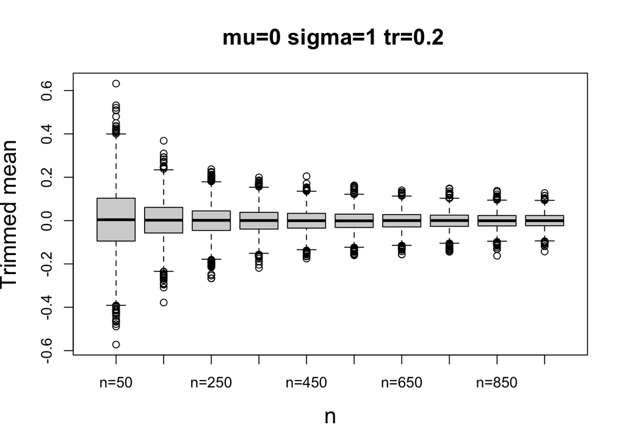

```r
n <- seq(50, 1000, by=100)
plotter("boxplot", n, mu, sigma, tr, N, seed)
```

### 2.3.2 Simple example of visualizing Monte Carlo Simulation Error, Empirical Variance, and Empirical Standard Error

#### 2.3.2.1 Simple example of visualizing Monte Carlo Simulation Error

If we are still interested in examining the effect of sample size, it can also help to display Monte Carlo Simulation Error (MCSE) and Empirical Variance (EmpVar) against varying sample size.

The formula of computing Monte Carlo Simulation Error (MCSE) is from Morris, White, and Crowther (2019) using

$$MCSE = \sqrt{\frac{{\text{Emp
Var}}}{2\cdot (N - 1)}},$$
where $\text{Emp Var}$ is the values of Empirical Variance and $N$ is the number of simulation times.

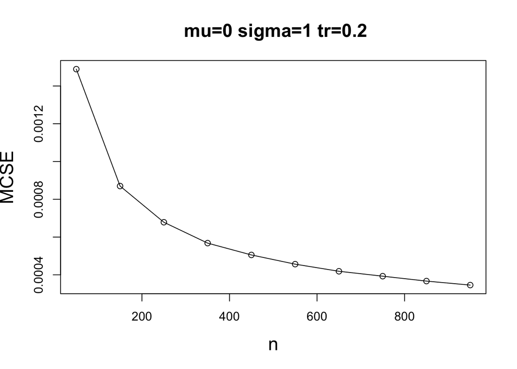

```r
n <- seq(50, 1000, by=100)
plotter("MCSE", n, mu, sigma, tr, N, seed)
```

To facilitate the comparison, we can also add other lines representing MCSE under different trimmed fraction on this figure.

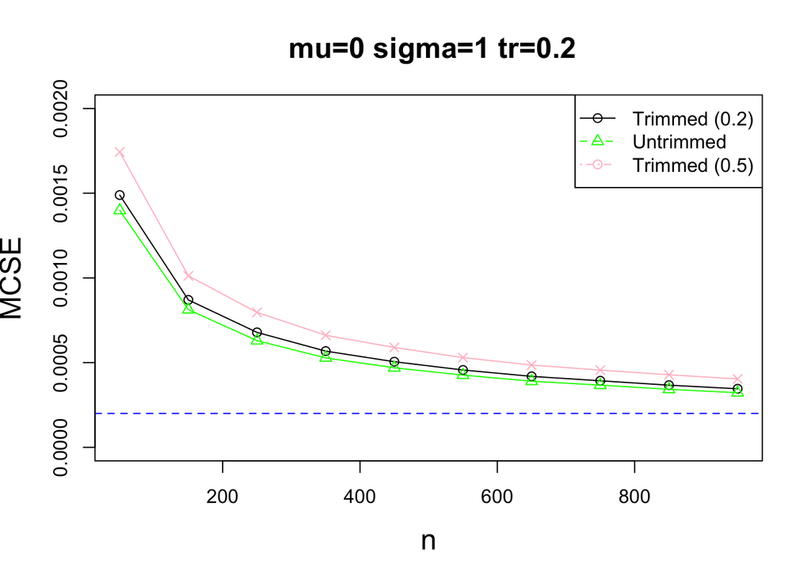

```r
n <- seq(50, 1000, by=100)
plotter("MCSE", n, mu, sigma, tr, N, seed, ylim = c(0,0.002))
plotter("MCSE", n, mu, sigma, tr=0, N,
        seed, add_to_plot = T, color="green", pch=2)
plotter("MCSE", n, mu, sigma, tr=0.5, N,
        seed, add_to_plot = T, color="pink", pch=4)
legend("topright", legend = c( "Trimmed (0.2)", "Untrimmed", "Trimmed (0.5)"),
       pch=c(1, 2), col = c("black", "green", "pink"), lty=c(1,2,4))
```

#### 2.3.2.2 Simple example of visualizing Empirical Variance

Note that in Emp Var plot, the blue dashed line corresponds to the level of empirical variance, such that the MCSE is 2e-04.

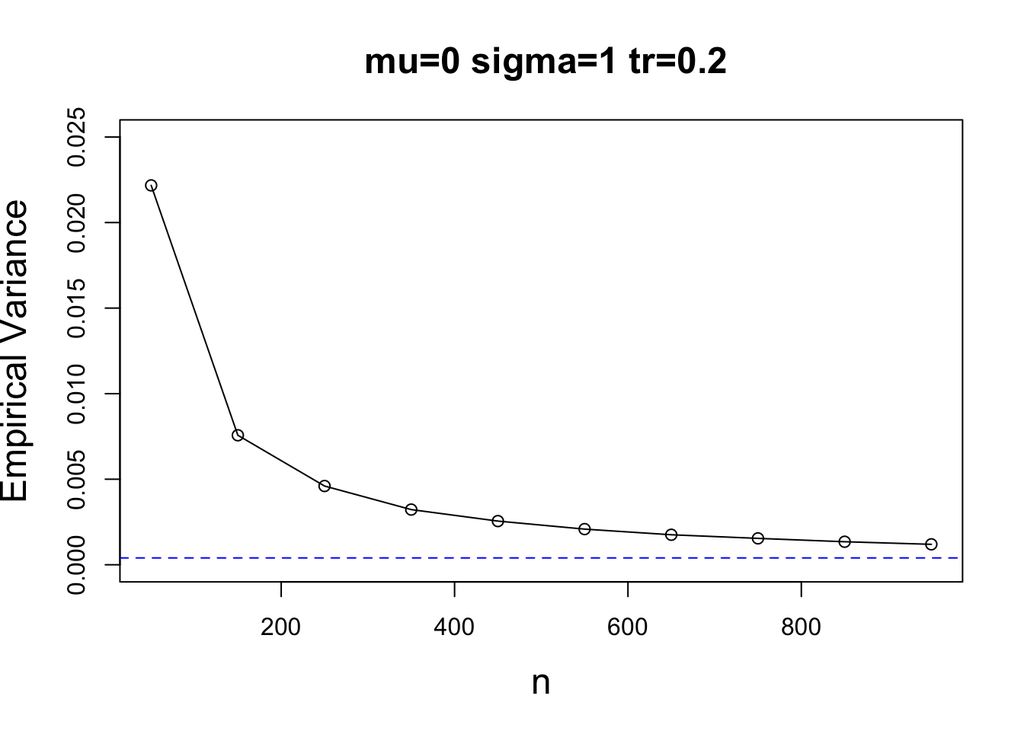

```r
n <- seq(50, 1000, by=100)
plotter("EmpVar", n, mu, sigma, tr, N, seed, ylim = c(0, 0.025))
```

It supports the comparison within one plot.

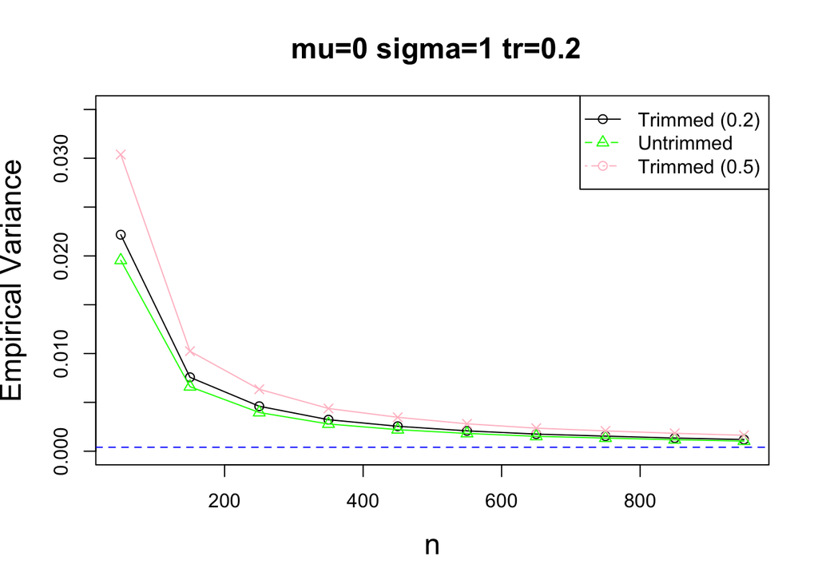

```r
n <- seq(50, 1000, by=100)
plotter("EmpVar", n, mu, sigma, tr, N, seed, ylim = c(0,0.035))
plotter("EmpVar", n, mu, sigma, tr=0, N,
        seed, add_to_plot = T, color="green", pch=2)
plotter("EmpVar", n, mu, sigma, tr=0.5, N,
        seed, add_to_plot = T, color="pink", pch=4)
legend("topright", legend = c( "Trimmed (0.2)", "Untrimmed", "Trimmed (0.5)"),
       pch=c(1, 2), col = c("black", "green", "pink"), lty=c(1,2,4))
```

#### 2.3.2.3 Simple example of visualizing Empirical Standard Error

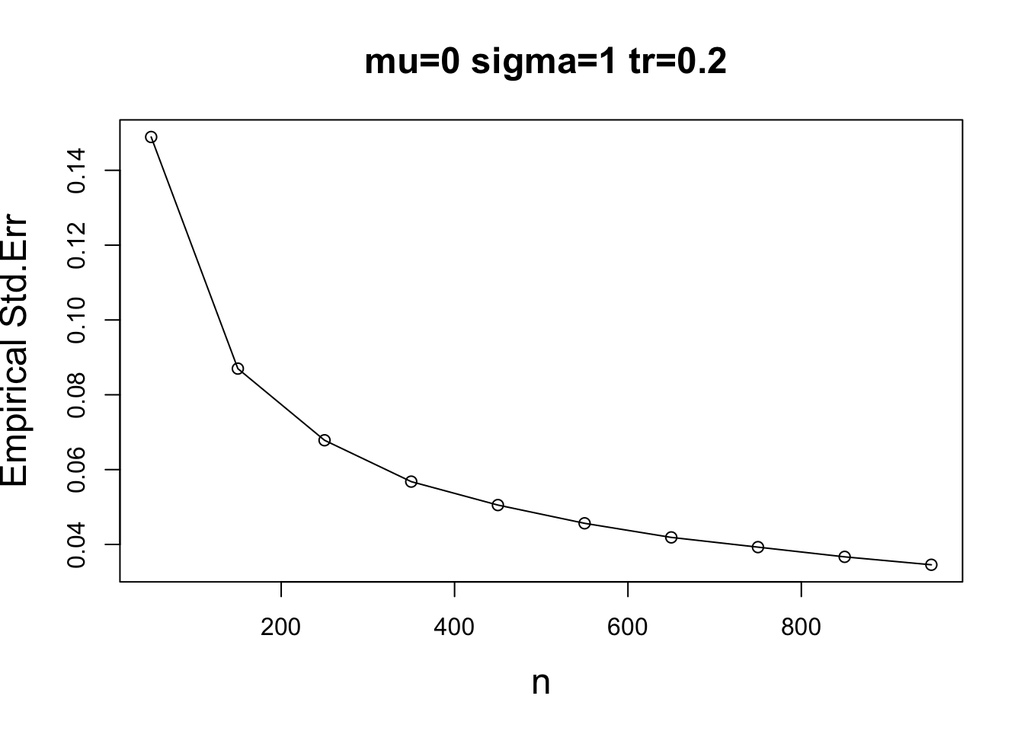

```r
n <- seq(50, 1000, by=100)
plotter("EmpSE", n, mu, sigma, tr, N, seed)
```

It also supports the comparison within one plot.

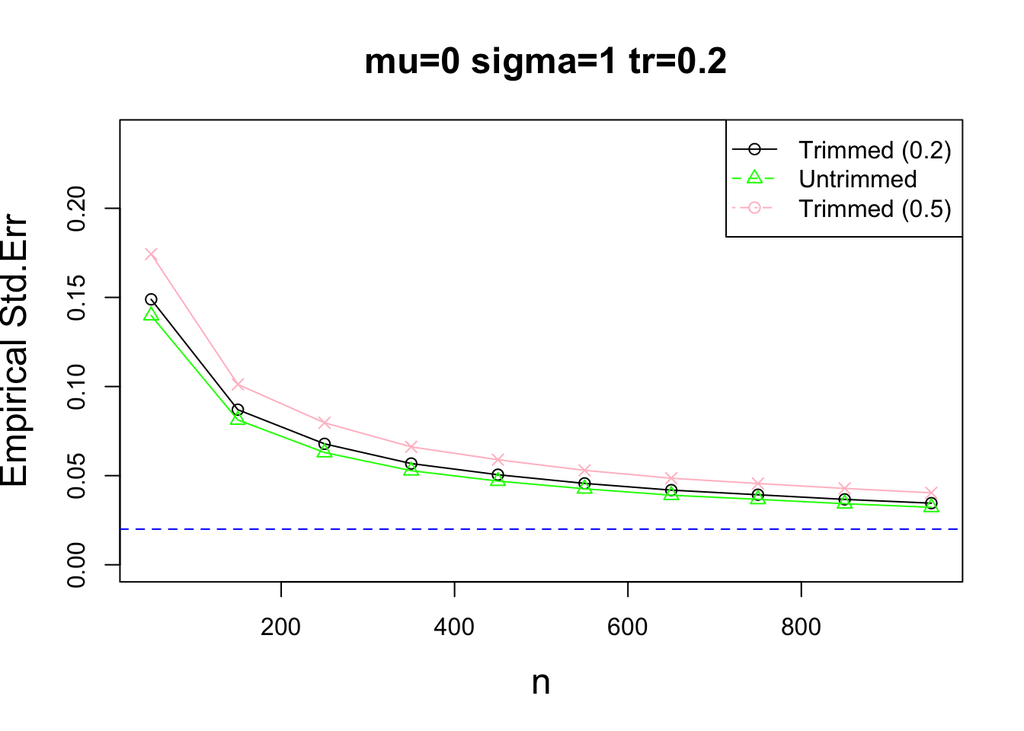

```r
n <- seq(50, 1000, by=100)
plotter("EmpSE", n, mu, sigma, tr, N, seed, ylim = c(0,0.24))
plotter("EmpSE", n, mu, sigma, tr=0, N,
        seed, add_to_plot = T, color="green", pch=2)
plotter("EmpSE", n, mu, sigma, tr=0.5, N,
        seed, add_to_plot = T, color="pink", pch=4)
legend("topright", legend = c( "Trimmed (0.2)", "Untrimmed", "Trimmed (0.5)"),
       pch=c(1, 2), col = c("black", "green", "pink"), lty=c(1,2,4))
```

### 2.3.3 Simple example of comparing empirical distribution using QQ-plot and ECDF

It supports comparison in the empirical distribution of trimmed mean estimates using QQ-plot and empirical cumulative distribution function(ECDF).

Suppose we want to compare the empirical distribution of trimmed mean estimates with trimmed proportion 0.2, 0.5 and untrimmed ones. We can visualize this comparison using ECDF.

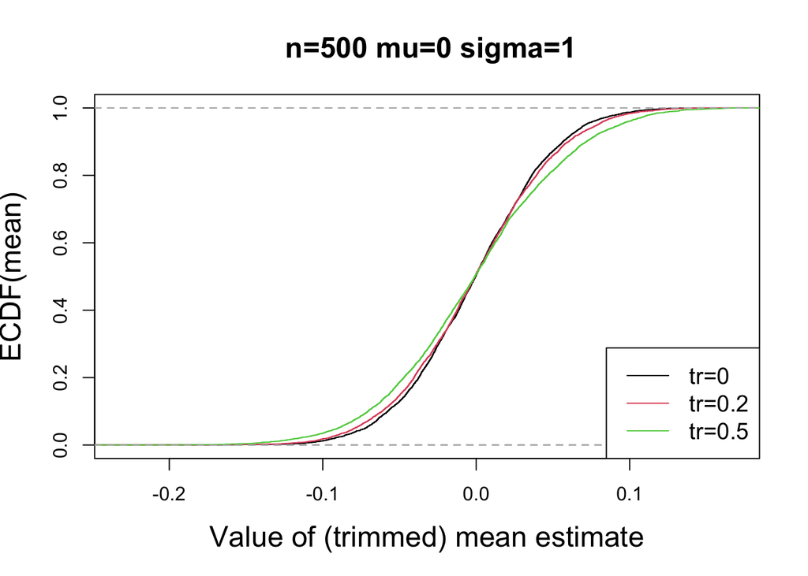

```r
n <- 500
plotter("ECDF", n, mu , sigma, tr=c(0,0.2, 0.5), N, seed)
```

QQ-plot can support pairwise comparison between two empirical distribution of trimmed estimates.

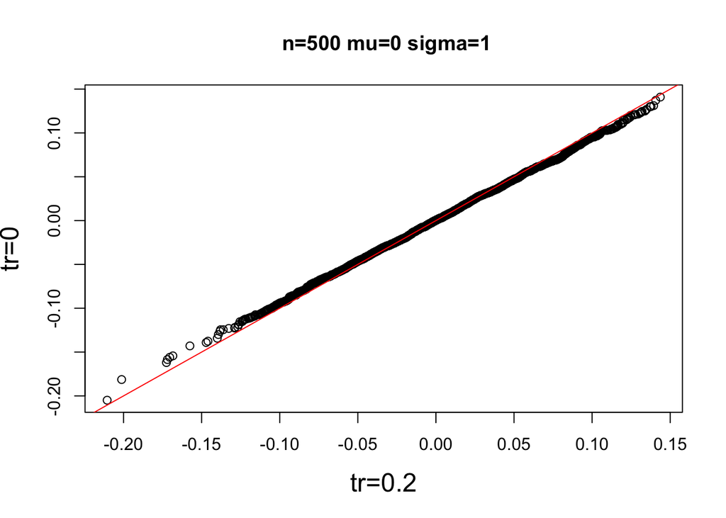

```r
plotter("QQplot", n, mu , sigma , tr=c(0.2, 0), N, seed)
```

We can also draw QQ-plot against the theoretical quantiles.

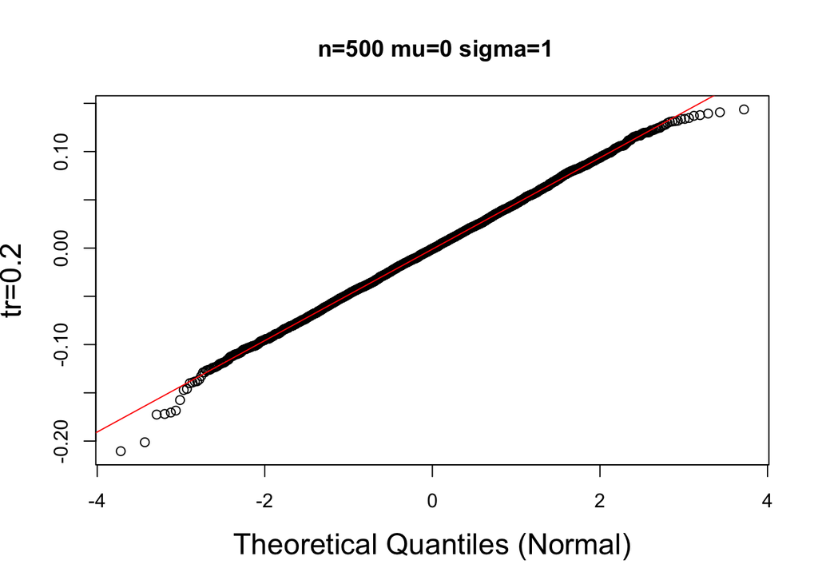

```r
plotter("QQplot", n, mu , sigma , tr , N, seed)
```

## 2.4 Basic examples of summarizing results using `tabler`

`tabler` function is used to provide a table summary of results, including bias, Empirical Variance (EmpVar),Empirical Standard Error (EmpSE) and Monte Carlo Simulation Error (MCSE). Most of the input arguments, including `n`, `mu`, `sigma`, `tr`, `N`, and `random.seed` are exactly same as the previous `getTrimMean()` function.

We can use `knitr::kable` function to give you a nicer formatted output.

```r
tab <- tabler(n, mu, sigma, seq(0,0.5, by=0.1), random.seed=1234)
tab
```

```
##                 Bias      EmpVar      EmpSE         MCSE
## tr=0   -9.702076e-05 0.001989928 0.04460861 0.0002575565
## tr=0.1 -2.444585e-04 0.002110796 0.04594340 0.0002652632
## tr=0.2 -2.135799e-04 0.002278953 0.04773838 0.0002756268
## tr=0.3 -1.943167e-04 0.002496229 0.04996227 0.0002884669
## tr=0.4 -1.174914e-04 0.002772205 0.05265173 0.0003039950
## tr=0.5  3.606240e-06 0.003122660 0.05588077 0.0003226385
```

```r
knitr::kable(tab, "markdown", digits = 4)
```

|  | Bias | EmpVar | EmpSE | MCSE |
| --- | --- | --- | --- | --- |
| tr=0 | -1e-04 | 0.0020 | 0.0446 | 3e-04 |
| tr=0.1 | -2e-04 | 0.0021 | 0.0459 | 3e-04 |
| tr=0.2 | -2e-04 | 0.0023 | 0.0477 | 3e-04 |
| tr=0.3 | -2e-04 | 0.0025 | 0.0500 | 3e-04 |
| tr=0.4 | -1e-04 | 0.0028 | 0.0527 | 3e-04 |
| tr=0.5 | 0e+00 | 0.0031 | 0.0559 | 3e-04 |

# 3 Simulation studies using `trimFZC` package

We would like to investigate the efficiency of the trimmed mean versus the untrimmed mean when the underlying distribution is normal and there is no contamination.

To do this, we need to randomly generate data from the normal distribution. Here, we vary the sample size parameter $n$ and fix $\mu = 0$, $\sigma = 1$.

We will consider sample sizes of: $5,15,50,250,500,1000$

We repeat this process $N$ times. To determine N, we investigate the Monte Carlo Standard Error (MCSE) of the empirical standard errors. The MCSE is calculated by
$$MCSE = \frac{\text{EmpSE}}{\sqrt{2*(N -
1)}}$$

We plot the MCSE for each value of $n$ listed above using $N = 5000$

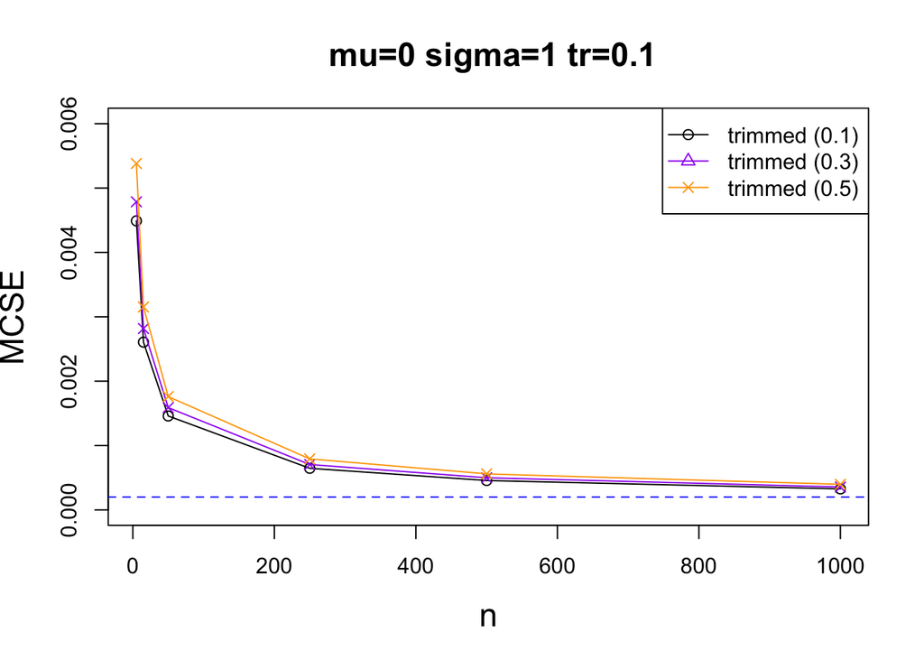

```r
par(mfrow=c(1,1))
plotter("MCSE", n=c(5,15,50,250,500,1000), mu=0, sigma=1, tr=0.1, N=5000,
        random.seed=20230619,ylim=c(0,0.006))
plotter("MCSE", n=c(5,15,50,250,500,1000), mu=0, sigma=1, tr=0.3, N=5000,
        random.seed=20230619, add_to_plot = T, color="purple", pch=4,ylim=c(0,0.006))
plotter("MCSE", n=c(5,15,50,250,500,1000), mu=0, sigma=1, tr=0.5, N=5000,
        random.seed=20230619, add_to_plot = T, color="orange", pch=4,ylim=c(0,0.006))
legend("topright", legend = c("trimmed (0.1)", "trimmed (0.3)","trimmed (0.5)"),
       pch=c(1, 2,4), col = c("black", "purple","orange"), lty=1)
```

From this plot we can see that the highest MCSE is below 0.006. This is an acceptable level of MCSE, and we decide to use $N=5000$.

We will now generate $N$ datasets for each value of $n$. Then on each generated data set we apply the following values of the trimming fraction: $0.1, 0.2, 0.3, 0.4, 0.5$

| Parameters | Values |
| --- | --- |
| $n$ | 5, 15, 50, 250, 500, 1000 |
| $\mu$ | 0 |
| $\sigma$ | 1 |
| tr | 0, 0.1, 0.2, 0.3, 0.4, 0.5 |

## 3.1 Results:

Lets take a look at the empirical standard error, but first recall that if $X \sim N(\mu, \sigma^2)$ then $\bar{X} \sim N(\mu, \frac{\sigma^2}{n})$. This result will be used to calculate the standard error of the untrimmed mean.

The empirical standard error:

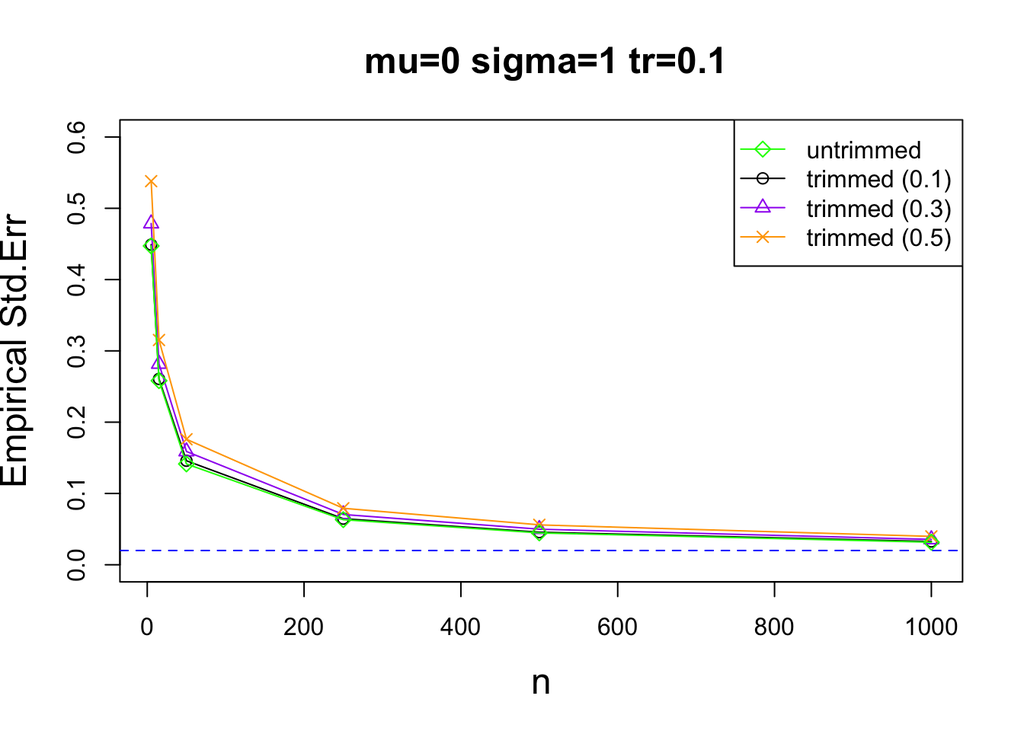

```r
n=c(5,15,50,250,500,1000)
plotter("EmpSE", n=n, mu=0 , sigma=1 , tr=0.1, N=5000, random.seed = 20230619,ylim=c(0,0.6))
plotter("EmpSE", n=n, mu=0, sigma=1, tr=0.3, N=5000,
        random.seed=20230619, add_to_plot = T, color="purple", pch=2,ylim=c(0,0.6))
plotter("EmpSE", n=n, mu=0, sigma=1, tr=0.5, N=5000,
        random.seed=20230619, add_to_plot = T, color="orange", pch=4,,ylim=c(0,0.6))
points(n, y=1/sqrt(n), col="green", pch=5)
lines(n, y=1/sqrt(n), col="green", pch=5)
legend("topright", legend = c("untrimmed", "trimmed (0.1)", "trimmed (0.3)","trimmed (0.5)"),
       pch=c(5, 1, 2,4), col = c("green", "black", "purple","orange"), lty=1)
```

From this plot we can see that for every sample size, the trimmed mean with trimming fraction equal to $0.1$ is very comparable to the untrimmed mean in regard to empirical standard error. As the trimming fraction increases, the empirical standard error increases.

We can investigate the sampling distributions of the trimmed mean estimates through boxplots:

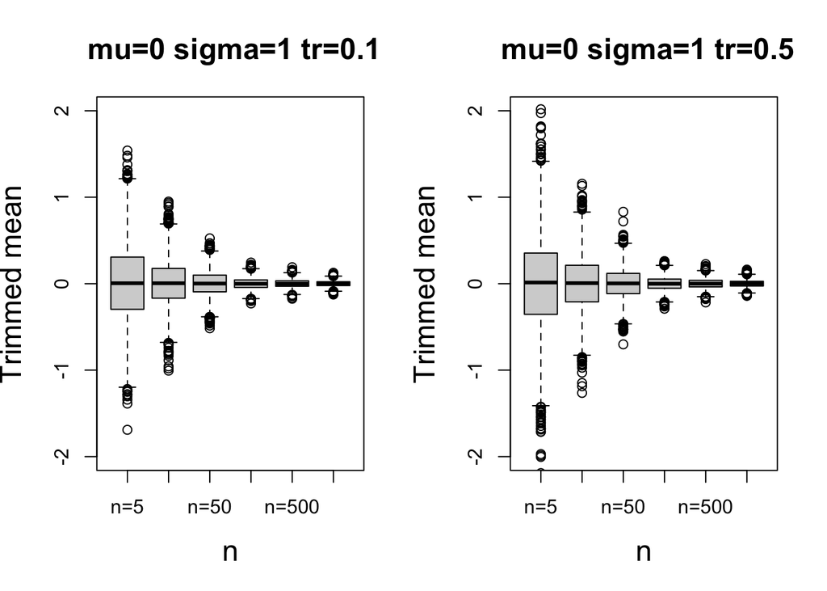

```r
par(mfrow=c(1,2))
n=c(5,15,50,250,500,1000)
plotter("boxplot", n=n, mu=0, sigma=1, tr=0.1, N=5000,
        random.seed=20230619, ylim=c(-2, 2))
plotter("boxplot", n=n, mu=0, sigma=1, tr=0.5, N=5000,
        random.seed=20230619, ylim=c(-2, 2))
```

From this we can see that the variability for each $n$ is larger for a trimming fraction of $0.5$ compared to $0.1$. It is difficult to compare $n=250,500,1000$, so we will plot these alone and investigate further.

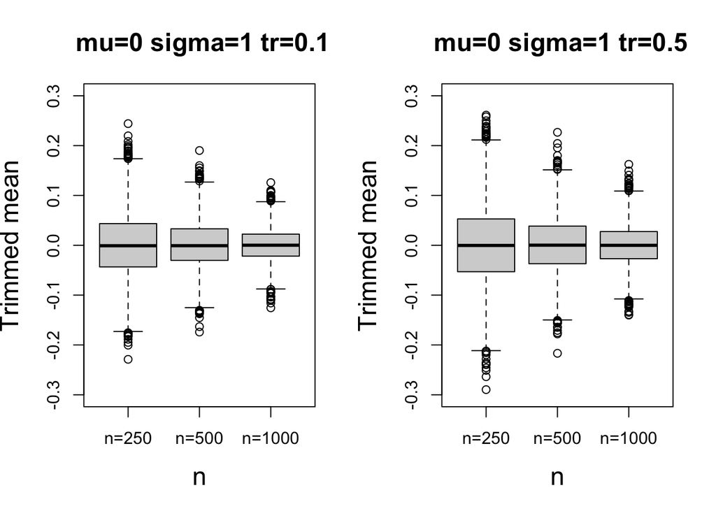

```r
par(mfrow=c(1,2))
n=c(250,500,1000)
plotter("boxplot", n=n, mu=0, sigma=1, tr=0.1, N=5000,
        random.seed=20230619, ylim=c(-0.3, 0.3))
plotter("boxplot", n=n, mu=0, sigma=1, tr=0.5, N=5000,
        random.seed=20230619, ylim=c(-0.3, 0.3))
```

From this plot, it is easier to tell that the trimming fraction of $0.5$ has larger variability than the trimming fraction of $0.1$.

We also compare the distributions through their empirical distribution functions (ECDF). Here, we plot the ECDF’s for each trimming fraction when $n=15$. The purple curve represents the cumulative distribution function for the sample mean.

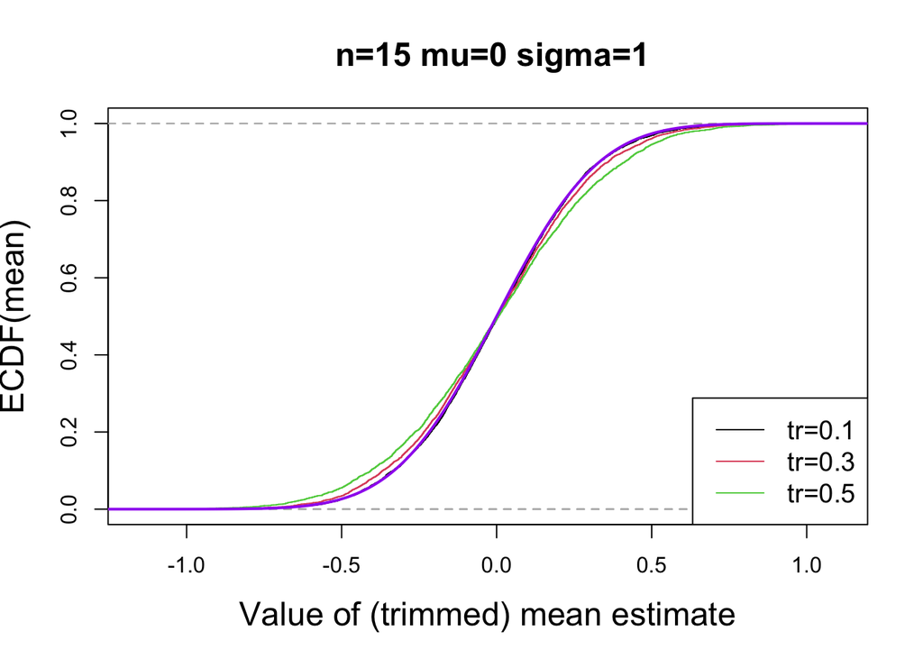

```r
plotter("ECDF", n=15, mu=0 , sigma=1 , tr=c(0.1,0.3,0.5), N=5000, random.seed = 20230619)
lines(seq(-2,2,by=0.01), pnorm(seq(-2,2,by=0.01),0,1/sqrt(15)), col="purple",type="l",lwd=2)
```

Here, we can see that a trimming fraction of $0.5$ has the least steep slope, indicating that there is more variability. This is consistent with the other plots we have examined.

The last plot we will look at is a QQ-plot to compare the sampling distributions of the trimmed mean to the theoretical quantiles of the distribution of the sample mean. First, lets look at a QQ-plot when $n=15$

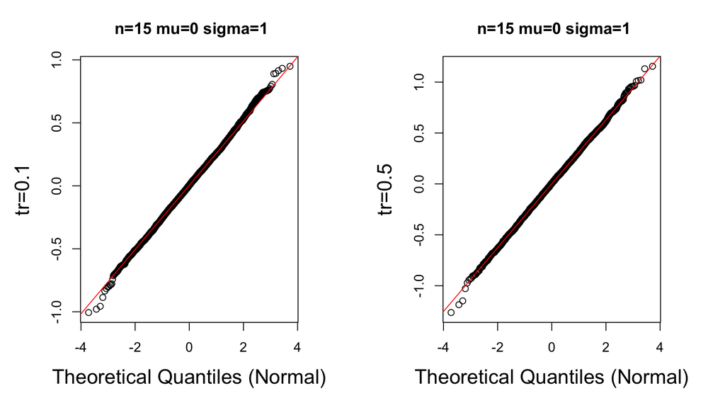

```r
par(mfrow=c(1,2), mai=c(1, 1, 0.7, 0.8))
plotter("QQplot", n=15, mu=0 , sigma=1 , tr=0.1 , N=5000, random.seed = 20230619)
plotter("QQplot", n=15, mu=0 , sigma=1 , tr=0.5 , N=5000, random.seed = 20230619)
```

Again, with $n=1000$

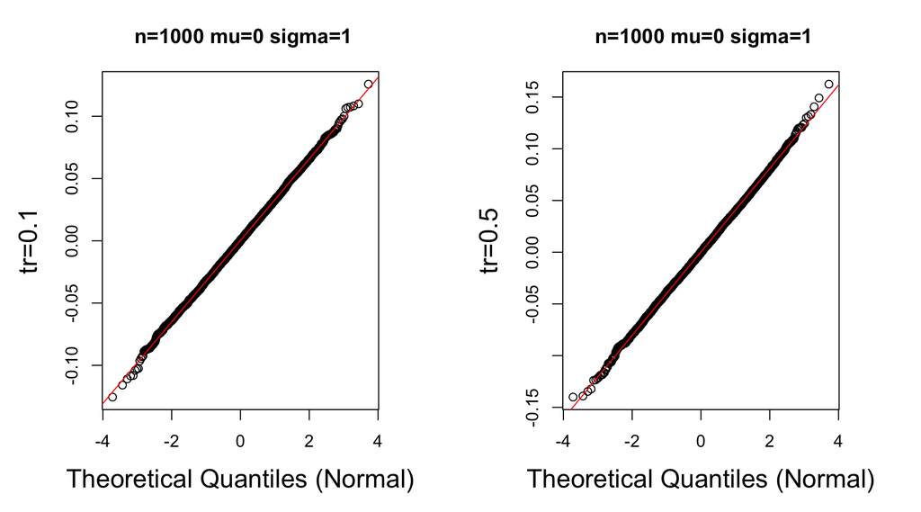

```r
par(mfrow=c(1,2), mai=c(1, 1, 0.7, 0.8))
plotter("QQplot", n=1000, mu=0 , sigma=1 , tr=0.1 , N=5000, random.seed = 20230619)
plotter("QQplot", n=1000, mu=0 , sigma=1 , tr=0.5 , N=5000, random.seed = 20230619)
```

Finally, we present the results of the study in tabular form

```r
tab = tabler(n=5, mu=0, sigma=1, tr=c(0.1,0.2,0.3,0.4,0.5), random.seed = 20230619)
knitr::kable(tab)
```

|  | Bias | EmpVar | EmpSE | MCSE |
| --- | --- | --- | --- | --- |
| tr=0.1 | 0.0034978 | 0.1966244 | 0.4434235 | 0.0025602 |
| tr=0.2 | 0.0029693 | 0.2246185 | 0.4739393 | 0.0027364 |
| tr=0.3 | 0.0029693 | 0.2246185 | 0.4739393 | 0.0027364 |
| tr=0.4 | 0.0042851 | 0.2864889 | 0.5352466 | 0.0030904 |
| tr=0.5 | 0.0042851 | 0.2864889 | 0.5352466 | 0.0030904 |

```r
tab = tabler(n=15, mu=0, sigma=1, tr=c(0.1,0.2,0.3,0.4,0.5), random.seed = 20230619)
knitr::kable(tab)
```

|  | Bias | EmpVar | EmpSE | MCSE |
| --- | --- | --- | --- | --- |
| tr=0.1 | 0.0015062 | 0.0682705 | 0.2612862 | 0.0015086 |
| tr=0.2 | 0.0014945 | 0.0754389 | 0.2746614 | 0.0015858 |
| tr=0.3 | 0.0015857 | 0.0799310 | 0.2827208 | 0.0016323 |
| tr=0.4 | 0.0015693 | 0.0917229 | 0.3028579 | 0.0017486 |
| tr=0.5 | 0.0022476 | 0.1012785 | 0.3182429 | 0.0018374 |

```r
tab = tabler(n=50, mu=0, sigma=1, tr=c(0.1,0.2,0.3,0.4,0.5), random.seed = 20230619)
knitr::kable(tab)
```

|  | Bias | EmpVar | EmpSE | MCSE |
| --- | --- | --- | --- | --- |
| tr=0.1 | 0.0008670 | 0.0211613 | 0.1454694 | 0.0008399 |
| tr=0.2 | 0.0007039 | 0.0228902 | 0.1512952 | 0.0008735 |
| tr=0.3 | 0.0009078 | 0.0250284 | 0.1582037 | 0.0009134 |
| tr=0.4 | 0.0009831 | 0.0278089 | 0.1667599 | 0.0009628 |
| tr=0.5 | 0.0011596 | 0.0307230 | 0.1752798 | 0.0010120 |

```r
tab = tabler(n=250, mu=0, sigma=1, tr=c(0.1,0.2,0.3,0.4,0.5), random.seed = 20230619)
knitr::kable(tab)
```

|  | Bias | EmpVar | EmpSE | MCSE |
| --- | --- | --- | --- | --- |
| tr=0.1 | 0.0003047 | 0.0042543 | 0.0652253 | 0.0003766 |
| tr=0.2 | 0.0002100 | 0.0046002 | 0.0678245 | 0.0003916 |
| tr=0.3 | 0.0001397 | 0.0050570 | 0.0711129 | 0.0004106 |
| tr=0.4 | 0.0001188 | 0.0056346 | 0.0750638 | 0.0004334 |
| tr=0.5 | 0.0002235 | 0.0063198 | 0.0794972 | 0.0004590 |

```r
tab = tabler(n=500, mu=0, sigma=1, tr=c(0.1,0.2,0.3,0.4,0.5), random.seed = 20230619)
knitr::kable(tab)
```

|  | Bias | EmpVar | EmpSE | MCSE |
| --- | --- | --- | --- | --- |
| tr=0.1 | 0.0002840 | 0.0021259 | 0.0461076 | 0.0002662 |
| tr=0.2 | 0.0002652 | 0.0022944 | 0.0478997 | 0.0002766 |
| tr=0.3 | 0.0003178 | 0.0025063 | 0.0500633 | 0.0002891 |
| tr=0.4 | 0.0003077 | 0.0027839 | 0.0527626 | 0.0003046 |
| tr=0.5 | 0.0001435 | 0.0031351 | 0.0559922 | 0.0003233 |

```r
tab = tabler(n=1000, mu=0, sigma=1, tr=c(0.1,0.2,0.3,0.4,0.5), random.seed = 20230619)
knitr::kable(tab)
```

|  | Bias | EmpVar | EmpSE | MCSE |
| --- | --- | --- | --- | --- |
| tr=0.1 | 0.0001167 | 0.0010614 | 0.0325784 | 0.0001881 |
| tr=0.2 | 0.0001547 | 0.0011460 | 0.0338523 | 0.0001955 |
| tr=0.3 | 0.0001947 | 0.0012568 | 0.0354515 | 0.0002047 |
| tr=0.4 | 0.0001637 | 0.0013984 | 0.0373951 | 0.0002159 |
| tr=0.5 | 0.0001434 | 0.0015750 | 0.0396858 | 0.0002291 |

We can see from the results in the table, the empirical standard error increases as the trimming fraction increases for each n. This increase is smaller in the case of $n=1000$.

# 4 Package Testings

## 4.1 R CMD Checks

As a general checking of the correct design and structure of this package, it is recommended to do conduct a R CMD Check, which can be simply done via the `check()` function in `devtools` package, i.e., `devtools::check()`.

Currently our package passes all the R CMD Checks.

## 4.2 Testing for Invalid Inputs

While the package is correctly setup, we considerately wrote some within-function tests that diagnose invalid inputs, using the `testthat` package. The tests are designed to return informative error messages in sake of easier debugging for users.

### 4.2.1 Testing `getTrimMean()`

The input parameters `(n, mu, sigma, tr, N)` all have to take numerical values, otherwise…

```r
library(trimFZC)
try(getTrimMean(n="10", N=5, mu=0, sigma=1, tr=0.1, random.seed = 1234))
```

```
## Error : all(...) is not TRUE
##
## `actual`:   FALSE
## `expected`: TRUE
## The parameters (n, mu, sigma, tr, N) all have to be numerical!
```

The input parameters `(n, mu, sigma, tr, N)` all have to take singular numerical value, so inputting vectors will cause error:

```r
try(getTrimMean(n=10, N=5, mu=0, sigma=c(0.5, 1, 2), tr=0.1, random.seed = 1234))
```

```
## Error : sum(...) not equal to 0.
## 1/1 mismatches
## [1] 1 - 0 == 1
## The parameters (n, mu, sigma, tr, N) all have to take singular numerical value!
```

The input parameters `(n, N, sigma)` cannot take 0 or negative number, otherwise…

```r
try(getTrimMean(n=10, N=-1, mu=0, sigma=1, tr=0.1, random.seed = 1234))
```

```
## Error : all(n > 0, N > 0, sigma > 0) is not TRUE
##
## `actual`:   FALSE
## `expected`: TRUE
## The parameters (n, N, sigma) cannot take 0 or negative numbers!
```

```r
try(getTrimMean(n=10, N=5, mu=0, sigma=1, tr=-2, random.seed = 1234))
```

```
## Error : all(tr >= 0, tr < 1) is not TRUE
##
## `actual`:   FALSE
## `expected`: TRUE
## The parameter 'tr' cannot take negative numbers or any numbers >= 1!
```

The input parameter `(tr)` can take 0 but cannot take negative values:

```r
try(getTrimMean(n=10, N=5, mu=0, sigma=1, tr=0, random.seed = 1234))
```

```
## [1] -0.3831574 -0.1181707 -0.3879468 -0.7661931 -0.6097971
```

```r
try(getTrimMean(n=10, N=5, mu=0, sigma=1, tr=-2, random.seed = 1234))
```

```
## Error : all(tr >= 0, tr < 1) is not TRUE
##
## `actual`:   FALSE
## `expected`: TRUE
## The parameter 'tr' cannot take negative numbers or any numbers >= 1!
```

The input parameters `(n, N)` have to take integers:

```r
try(getTrimMean(n=10, N=5.5, mu=0, sigma=1, tr=0, random.seed = 1234))
```

```
## Error : all(N == round(N), n == round(n)) is not TRUE
##
## `actual`:   FALSE
## `expected`: TRUE
## The parameters (N, n) have to be integers!
```

### 4.2.2 Testing `plotter()`

The input argument `plot_type` can only take value from the list: `['boxplot', 'MCSE', 'EmpVar', 'EmpSE', 'QQplot', 'ECDF']`, otherwise…

```r
try(plotter("trimFZC", n=100, N=500, mu=0, sigma=1, tr=seq(0, 0.5, by=0.1), random.seed = 1234))
```

```
## Error : plot_type %in% ... is not TRUE
##
## `actual`:   FALSE
## `expected`: TRUE
## Wrong plot_type! plot_type has to be one of
##               ['boxplot', 'MCSE', 'EmpVar', 'EmpSE', 'QQplot', 'ECDF'].
```

All of the input parameters `(n, N, mu, sigma, tr)` have to take numerical values:

```r
try(plotter("boxplot", n=100, N=500, mu=c(0, 1, "mu"), sigma=1, tr=seq(0, 0.5, by=0.1), random.seed = 1234))
```

```
## Error : all(is.numeric(n), is.numeric(mu), is.numeric(sigma), is.numeric(tr)) is not TRUE
##
## `actual`:   FALSE
## `expected`: TRUE
## The sample size (n), grounding true mean (mu),
##               groudning true standard deviation (sigma),
##               and trim ratio (tr) all have to take numerical values!
```

None of the input parameters `(n, mu, sigma, tr)` can take `NULL` or empty value.

```r
try(plotter("boxplot", n=numeric(), N=500, mu=0, sigma=1, tr=seq(0, 0.5, by=0.1), random.seed = 1234))
```

```
## Error : all(...) is not TRUE
##
## `actual`:   FALSE
## `expected`: TRUE
## All of (n, mu, sigma, tr, N) cannot take empty or NULL values.
```

And since we only allow one parameter to vary each time (holding all other parameters fixed), exactly one of the input parameters `(n, mu, sigma, tr)` has to take a numeric vector of length greater than 1. And the other parameters have to take singular numerical values.

```r
try(plotter("boxplot", n=100, N=500, mu=c(0, 1), sigma=1, tr=seq(0, 0.5, by=0.1), random.seed = 1234))
```

```
## Error : sum(c(length(n), length(mu), length(sigma), length(tr)) != 1) not equal to 1.
## 1/1 mismatches
## [1] 2 - 1 == 1
## If plotting boxplot, MCSE, EmpVar, EmpSE or ECDF with one parameter varying,
##                 then the other 3 parameters have to be fixed as constant. So, exactly one of
##                 (n, mu, sigma, tr) has to take a vector of length larger than 1, and the other
##                 arguments have to take singular numerical values.
```

```r
try(plotter("ECDF", n=100, N=c(500, 3000), mu=0, sigma=1, tr=c(0, 0.1, 0.2, 0.3), random.seed = 1234))
```

```
## Error : sum(...) not equal to 0.
## 1/1 mismatches
## [1] 1 - 0 == 1
## The parameters (n, mu, sigma, tr, N) all have to take singular numerical value!
```

In particular, when we are generating QQplot, this is a pairwise comparison of the distribution of trimmed mean estimates. So, at most one of the `(n, mu, sigma, tr)` can take a vector of length no greater than 2. When all of `(n, mu, sigma, tr)` are singular numerical inputs, we are comparing one sample of trimmed mean estimates with its theoretical distribution.

```r
try(plotter("QQplot", n=100, N=500, mu=0, sigma=1, tr=c(0, 0.5, 0.4), random.seed = 1234))
```

```
## Error : all(...) is not TRUE
##
## `actual`:   FALSE
## `expected`: TRUE
## If plotting QQplot, then at most one of the (n, mu, sigma, tr)
##                  can take a vector of length no greater than 2.
```

When we are generating line plots (e.g., MCSE, EmpVar, EmpSE), we can draw a line on an existing plot by setting `add_to_plot = TRUE`. But if there is no existing plot,

```r
try(plotter("EmpVar", n=100, N=500, mu=0, sigma=seq(1,10, by=1), tr=0.3, random.seed = 1234,
    add_to_plot = T, color="green", pch=2))
```

```
## Error in plot.xy(xy.coords(x, y), type = type, ...) :
##   plot.new has not been called yet
```

Also, the argument `add_to_plot` has to take logical inputs:

```r
try(plotter("EmpVar", n=100, N=500, mu=0, sigma=seq(1,10, by=1), tr=0.3, random.seed = 1234,
    add_to_plot = 123, color="green", pch=2))
```

```
## Error : class(add_to_plot) == "logical" is not TRUE
##
## `actual`:   FALSE
## `expected`: TRUE
## 'add_to_plot' has to take logical values, i.e., TRUE or FALSE.
```

Lastly, `plotter()` also has arguments `ylim, color, linetype, pchar`, which respectively correspond to `ylim, col, lty, pch` arguments in the basic `graphics::plot()` function in R. So, we did not write tests in `plotter()` for them, as they already exist. For example, `ylim` can only take a numeric vector of length 2:

```r
try(plotter("EmpVar", n=100, N=500, mu=0, sigma=seq(1,10, by=1), tr=0.3, random.seed = 1234, ylim=c(1,2,3)))
```

```
## Error in plot.window(...) : invalid 'ylim' value
```

### 4.2.3 Testing `tabler()`

When creating the tabularized results, we don’t allow the parameter `N` to vary anymore, as this should be fixed at the beginning of the analysis.

```r
try(tabler(n=100, mu=0, sigma=1, tr=0.1, N=c(500, 510), random.seed = 1234))
```

```
## Error : N == round(N) is not TRUE
##
## `actual`:   TRUE TRUE
## `expected`: TRUE
## The parameter N has to take an integer!
```

For simplicity of the table, we only allow one paramter to vary at a time, fixing all other parmeters fixed as constant. So, at most one of `(n, mu, sigma, tr)` can a a vector of length greater than 1.

```r
try(tabler(n=100, mu=0, sigma=c(0.5, 1, 2), tr=seq(0, 0.5, by=0.1), N=500, random.seed = 1234))
```

```
## Error : ... <= 1 is not TRUE
##
## `actual`:   FALSE
## `expected`: TRUE
## At most one of (n, mu, sigma, tr) can take a vector of length
##                          larger than 1.
```

When one parameter take a vector of length greater than 20, we return a warning message as too many rows can cause the table messy.

```r
try(tabler(n=100, mu=0, sigma=1, tr=seq(0, 0.5, by = 0.005), N=500, random.seed = 1234))
```

```
## Warning in tabler(n = 100, mu = 0, sigma = 1, tr = seq(0, 0.5, by = 0.005), :
## Input parameter tr contains too many entries, causing too many rows in the
## tabularized output!
```

# References

Kim, Seong-Ju. 1992. “The Metrically Trimmed Mean as a Robust Estimator of Location.” *The Annals of Statistics* 20 (3): 1534–47. https://doi.org/10.1214/aos/1176348783.

Morris, Tim P, Ian R White, and Michael J Crowther. 2019. “Using Simulation Studies to Evaluate Statistical Methods.” *Statistics in Medicine* 38 (11): 2074–2102.